# ¿Qué mueve a Bitcoin?

### Reporte de proyecto final estadística aplicada 3

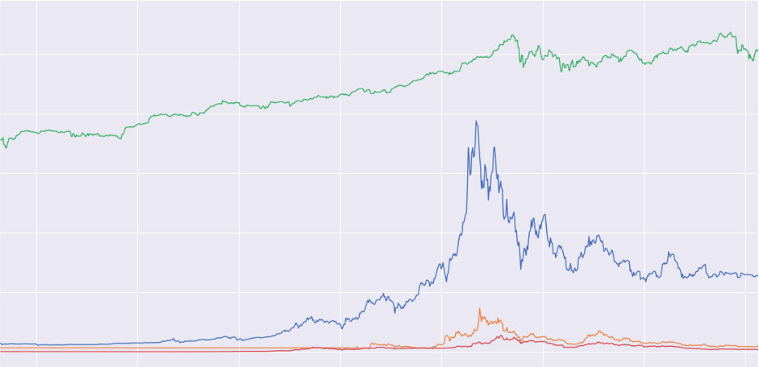

### Índice

- Introducción
- Exploración de los datos
- Modelos predictivos
- Simulación de portafolios
- Conclusiones

## Introducción

El Bitcoin es una criptomoneda descentralizada sin un administrador o banco central. Fue creada en 2008 por un usuario desconocido llamado "Satoshi Nakamoto". Se puede adquirir Bitcoin a través de "minarlos" o por una compraventa directa entre usuarios, pero el precio no depende de un subyacente o de algún valor intrínseco, el precio se determina por oferta y demanda.

El proceso para minar un Bitcoin requiere de dos pasos:

1. Verificar que la información de 1 MB de transacciones sea válida, esto puede ser una transacción o miles de transacciones dependiendo de la información de cada una. Esta parte es relativamente rápida y una vez que se cumple el paso número dos se agregara este bloque de 1 MB a la información pública de las transacciones.
2. Una vez validada la información de las transacciones el usuario que está minando los Bitcoin se vuelve elegible para poder ganar los bitcoins, pero para mantener el número de bloques agregados al "Blockchain" constante durante el tiempo se hizo un proceso llamado "Proof-of-Work". En este proceso los usuarios que están intentando minar requiere encontrar un "hash", un número hexagecimal de 64 bits que cumpla con los requerimientos establecidos por el programa. Encontrar este número tiene una probabilidad de 1 en 13 trillones, por lo que se requiere gran capacidad computacional y recursos para encontrarlo. Una vez que se encuentra el "target hash" entonces el nuevo bloque se acepta y el usuario que encontro el hash recibe un premio de Bitcoins, adicionado a las comisiones por transacción correspondientes al bloque.

De está forma los usuarios que minan Bitcoin mantienen las transacciones validadas y por lo tanto hacer fraude se vuelve poco viable por la cantidad de recursos y de poder computacional necesario para poder encontrar los "target hash" más rápido que los demás y que las transacciones sean validadas después de agregar un bloque.

El premio obtenido por minar se divide a la mitad cada 210,000 bloques que se agregan, lo que tarda alrededor de 4 años. El objetivo de esto es que Bitcoin agregue valor por la escasez ya que habrá, en algún momento, un número finito de Bitcoins sin la posibilidad de minar más, pero para mantener el incentivo para que los mineros mantengan seguro el proceso de transacciones se agrega una comisión, misma que aumenta conforme disminuye el premio por minar.

Por otro lado, el movimiento de Bitcoin a través de tiempo ha sido muy volátil. Hace menos de tres años el precio de Bitcoin era de alrededor de 1,000 USD , mientras que el precio al 1 de Diciembre de 2019 es de alrededor de 7,400 USD, una apreciación de 640%, pero no solo esto, el precio alcanzó niveles de casi 19,000 USD antes de caer un 25% en menos de 2 dias. Por lo tanto, el Bitcoin ha estado sujeto a grandes cambios en precio, una volatilidad que hace que las inversiones en esta criptomoneda sean muy riesgosas y poco atractivas para inversionistas que buscan rendimientos más moderados con riesgo controlado.

Es así como llegamos a nuestra hipótesis de trabajo:

**¿Se puede predecir el movimiento del Bitcoin a través del análisis de noticias?**

El objetivo del presente trabajo es implementar diferentes predicciones a través de modelos estadísticos para intentar ver si existe una relación entre las palabras que aparecen en las noticias de Fox Business News y el movimiento de Bitcoin. Adicionalmente, en caso de que sí exista una relación entre ambos, buscamos ver si esta nos puede ayudar a predecir el movimiento futuro de la criptomoneda y monetizar estas predicciones a través de portafolios.

Para nuestro análisis de noticias nos basamos en los encabezados de noticias de un periódico americano. La forma en la que analizamos las noticias fue a través de ver el número de apariciones de las palabras individuales y de algunas parejas de interés. Por lo tanto, para cada observación tomamos como variables explicativas el número de veces que apareció esa palabra en los títulos del día.

Es importante mencionar que el Bitcoin no se intercambia en una bolsa regulada, sino que se intercambia directamente entre usuarios, "peer-to-peer", la gran mayoría de ellos entre usuarios de Wallets. Por esta razón siempre se puede intercambiar Bitcoin, en cualquier momento del día pero para poder medir un cambio diario se tomó un precio de apertura, "open" y de cierre de los mercados tradicionales "price".

Finalmente, aprovechado la liquidez del mercado observaremos cuál hubiera sido la evolución de un Capital de **MXN$ 100,000** sobre una posición dinámica en Bitcoin.

## Análisis exploratorio de los datos

Recordemos que nuestra variable objetivo es el cambio en **open** vs. **price**, una variable categórica. Acompañada de esta variable hay otras que definen al mercado de bitcoin para cada día. Estas son **high**,**low** entre otras. Sin embargo, al ver las correlaciones con nuestra variable objetivo estás resultaron ser muy bajas, es claro que modelos de series de tiempo podrían interpretar mejor estas variables sin embargo no es este el enfoque de este proyecto.

Es aquí donde surgen los conceptos de procesamiento de lenguaje natural (**NLP**). La información que nuestro modelo utilizará para predecir nuestra variable objetivo **open** vs. **price** provendrá de encabezados periodísticos como se menciona en la introducción. Es prudente presentar aquí 2 conceptos nuevos. **Text-Vectorizers** y **N-gramas**.

Un **Text-Vectorizer** no es más que una forma de vectorizar texto, valga la redundancia, es decir asignar a cada palabra o texto un vector en algún espacio. Existen muchas formas de hacer esto, algunos asignan el vector $e_{i}$ para cada palabra $i$ en tu **Vocabulario**. Osea todas las palabras en tu Corpus. Algunas, otras formas de vectorizar texto asignan un vector a cada palabra que codifica contexto en la geometría particular del espacio multidimensional, como el espacio **Word2Vec**. En nuestro caso particular se utilizó un vectorizador que cuenta las ocurrencias de cada palabra y cada 2-palabras en las noticias durante 12 horas al día, previas a la apertura del mercado Bitcoin.

Para entender mejor palabra y 2-palabras es que existe el concepto de **N-gram** o **N-gramas**. Veamos un ejemplo con la oración

**Bitcoin es un mercado muy volátil pero muy efectivo, viva Bitcoin**

En la oración anterior todos los 1-gramas conformarían la lista:

- Bitcoin
- es
- un
- mercado
- etc.

Una entrada por palabra. La lista de 2-gramas o como mencionamos, 2-palabras sería:

- Bitcoin es
- es un
- un mercado
- mercado muy
- etc.

Estas 2-palabras sirven para extraer información de parejas de palabras que muchas veces van juntas, como puede ser **Nueva York**. Ahora que ya entendimos supongamos que la oración anteriormente escrita fue el único headline durante 12 horas. A esta observación junto con el precio de **open**, **price** y nuestra variable objetivo. Se le añadiría un vector en donde se contaran las ocurrencias de cada 1-palabra y 2-palabra. Es decir valdría 1 en la entrada correspondiente a `mercado` pues se mencionó una sola vez y 2 en la casilla de `Bitcoin` y `muy` pues se mencionaron 2 veces y así para todo el vocabulario de n-gramas.

Para entender mejor nuestros datos veamos la siguiente gráfica con 2 ejes:

[figure not shown]

**Figura 1.** Palabras interesantes, open, price y nuestra variable objetivo.

Cómo se puede ver en la figura 1, en cada fecha en la que existe una observación de los valores del mercado de Bitcoin hay también el número de ocurrencias de palabras como **elon** y otras. Es decir cuántas veces surgió la palabra en los encabezados de 12 horas antes de la observación de cada valor de **open**. Es díficil extraer información sólo de esta gráfica, además que nuestro dataset ¡tiene ocurrencias de **2960** palabras y 2-palabras!

Es importante mencionar que el preprocesamiento que se tiene que hacer para extraer un set de datos así de limpio no es sencillo, por suerte existen herramientas cómo [OpenBlender](https://www.openblender.io) que facilitan todo este trabajo. Obtener un set de datos de encabezados de otras fuentes de noticias matcheados con valores numéricos de otros mercados y con ventanas de 12 horas u otras configuraciones se puede lograr con una sola llamada a su **API**, esta llamada esta pensada para que usuarios de **R** y **Python** puedan entrenar modelos de **NLP** u otras técnicas de machine learning de una forma muy fluída, datos y variables objetivo directo a tu `DataFrame`.

Para seguir la exploración de nuestros datos veamos de que hablan estas nuestros encabezados mayoritariamente, mostrando las palabras con **más** ocurrencias de entre todas nuestras **68** observaciones:

[figure not shown]

**Figura 2.** Palabras y 2-palabras más mencionadas en toda nuestra muestra.

Es claro el sesgo que tiene nuestro dataset hablando de `trump`, `china` y otros temas de la actualidad, sin embargo, que tanto pueden estos temas afectar al mercado de Bitcoin, para obtener más insight veamos los n-gramas más y menos correlacionados con nuestra variable objetivo:

[figure not shown]

**Figura 3.** Palabras más y menos correlacionadas con el cambio positivo entre la apertura y cierre de bitcoin.

Interpretar estas ocurrencias puede ser peligroso, sin embargo, nuestra intuición podría generar algunas hipótesis iniciales:

- Puede el **impeachment** afectar el precio del dolar y así incentivar la compra de bitcoin?
- **Elon Musk** tiene grandes inversiones en Bitcoin, el exito o fracaso de sus proyectos mueve a bitcoin?

Estas y otras narrativas pueden generarse a partir de un análisis más profundo, prosigamos a mejorar la idea que tenemos de nuestra base de datos haciendo **PCA**, es decir, reducir la dimensionalidad de nuestras más de 2900 variables y proyectarlas en lo que podría ser *la mejor foto* de nuestras observaciones. O explicado de otra forma 2 ejes ortogonales que maximizan la varianza total:

[figure not shown]

**Figura 4.** Nuestra base de datos en su primeras 2 componentes principales.

En esta proyección parece complicado encontrar algún corte que nos permita segmentar nuestras observaciones para generar un pronóstico adecuado de nuestra variable objetivo, sin embargo estos 2 componentes principales no explican ni el **10%** del total de la varianza de nuestras observaciones, sobretodo por la alta dimensionalidad de cada una de las observaciones. Por suerte nuestras correlaciones en la figura 3 nos mantienen entusiastas de extraer información de los encabezados para una buena predicción.

## Modelos Predictivos

Recordemos que la variable que nos interesa predecir es **Positive change (open vs. price)**, es decir 2 clases:

- 1 si la diferencia entre price y open fue **positiva**.
- 0 si fue **negativa**.

Cómo se trata de un clasificador binario se intentaron los siguientes modelos:

- **LDA**
- **QDA**
- **Regresión lógistica**
- **Random Forest**

Para entrenarlos se usó el primer **70%** y para probarlos el último **30%** de nuestras observaciones en orden temporal.

Entre los modelos mencionados anteriormente **LDA** y la **Regresión logística** son modelos lineales, mientras que **QDA** y **Random Forest** no. **LDA** y **QDA** se refieren a análisis discriminante lineal y cuadrático respectivamente. Estos 2 modelos buscan encontrar una función lineal o cuadrática que maximice la distancia entre los grupos que genera la variable objetivo, pero que al mismo tiempo minimice la densidad en cada grupo.

El problema de algunos de estos modelos es la dificultad que existe para interpretar los resultados que generan, sobre todo en el caso de la **Regresión logística** y el bosque aleatorio. Por ejemplo el **Random Forest**, es un modelo que genera árboles de decisión aleatorios que se ajustan de tal forma que maximicen los resultados en la predicción.

Todos estos modelos fueron evaluado y sorprendentemente **LDA**, el modelo más sencillo, resultó ser el mejor en predecir nuestra variable objetivo con una precisión del **63%**. Cabe mencionar que el resto de los modelos generaron precisiones menores pero todas mayores al 50%. Evidencia suficiente para soportar nuestra hipótesis de trabajo. Veamos ahora las correlaciones más importantes entre nuestras observaciones proyectadas a la función discriminante lineal y los n-gramas:

[figure not shown]

**Figura 5.** Correlaciones entre n-gramas y las observaciones proyectadas en la función discriminante.

Estas correlaciones pueden ser interpretadas de la siguiente forma, una correlación alta aumenta el valor en la función discriminante y una baja la disminuye. Esta función tiene como objetivo separar nuestras etiquetas dadas por la variable objetivo, es decir a partir de un valor en nuestra función discriminante seremos capaces de predecir que el cambio entre **price** y **open** será positivo, mientras que si el valor es menor, predeciremos que el cambio será negativo. Para entender mejor esta predicción veamos el siguiente mapa territorial:

[figure not shown]

**Figura 6.** Mapa territorial generado a partir del modelo LDA ajustado.

Cada una de las observaciones, es decir, las ocurrencias de palabras en 12 horas de encabezados se proyecta a esta función discriminante definida en el eje vertical. El corte que separa los territorios es el que nos permite generar nuestra predicción, es decir en el territorio inferior predeciremos que el cambio será negativo, es decir que el precio bajará y en el superior lo contrario. De esta forma lo ideal sería que todos las observaciones azules estuvieran en el territorio inferior y las naranjas en el superior. A pesar de los errores nuestra predicción es mucho mejor que la que daría lanzar una moneda, veamos la siguiente matriz de confusión generada por nuestro modelo:

[figure not shown]

**Figura 7.** Matriz de confusión generada a partir de las predicciones obtenidas por el modelo LDA.

## Simulación de portafolios

Como primer paso observamos si el precio de Bitcoin aumentará y disminuirá en el próximo dia, adicionalmente observamos cuál es la evolución de un portafolio dinámico con un capital de MXN$ 100,000. Para poder determinar esta evolución, nos basamos en un portafolio dinámico, es decir, este portafolio cambia de posición diariamente conforme se hace la predicción sobre el movimiento del Bitcoin antes del momento de apertura de mercado.

Nuestro portafolio dinámico funciona de la siguiente manera. La posición, larga o corta, la definimos así:

$$Pos_{t+1} = 1 \text{ si la predicción es 1}.$$

$$\text{ } Pos_{t+1} = -1 \text{ si la predicción es 0}.$$

Donde una posición de 1 representa una posición larga en Bitcoin, es decir, compramos Bitcoin con el objetivo de venderlos al precio de cierre. Si nuestra predicción es correcta y el precio del Bitcoin aumenta esto representa una ganancia para el inversionista ya que venderá a un precio por arriba del precio de compra. Por el otro lado, una posición de -1 representa una posición corta en Bitcoin, es decir, pedimos prestado el Bitcoin y lo vendemos en el momento, lo que le debemos Bitcoin a otro inversionista. Al final del día al momento de cierre de los mercados tradicionales nosotros debemos de recomprar el Bitcoin para regresarselos al dueño original, por lo tanto, si nuestra predicción es correcta entonces esto representa una ganancia ya que vendimos a un precio por arriba del precio de recompra.

Veamos también que para la evolución del capital importa que la predicción sea correcta y no hay diferencia entre los errores de tipo I y tipo II, digamos falsos positivos y falsos negativos, ya que en ambos casos perdemos dinero y en el contexto del problema ninguno es peor que otro. Por lo tanto nos fijaremos solamente en que la predicción sea correcta y por razones que se explicarán a continuación es muy importante concentrarse en el rendimiento.

Ahora, la evolución del capital cambiará de la siguiente manera:

$$Capital_{t+1} = Capital_{t} * (1+rendimiento_{t+1} * Pos_{t+1})$$

$$\text{dónde } rendimiento_{t+1} = \frac{precio_{t+1}}{\text{precio apertura}_{t+1}} - 1$$

Si el rendimiento es negativo y nuestra predicción fue acertada entonces tomamos una posición corta en la acción, lo que representa una ganancia en capital. Veamos que la única forma en la que tengamos una pérdida en capital es que nuestra predicción sea incorrecta, ya que de esta forma la multiplicación rendimiento y posición tiene signos contrarios y por lo tanto tenemos rendimiento total negativo. Aquí vemos que no solamente es importante tener la predicción correcta sino que el rendimiento será parte primordial del análisis. Si predecimos correctamente los días de poca variabilidad en el precio, i.e. , días de bajo rendimiento en valor y predecimos incorrectamente los días de gran variabilidad en precio, i.e. , días de alto rendimiento en valor absoluto, podemos incurrir en pérdidas aunque el nivel de precisión del modelo sea mayor al 50$\%$

Adicionalmente es imporante ver que supuestos tomamos para poder modelar la simulación de los portafolios. Recordemos que el modelo se entrenó con el 70$\%$ de los datos y este mismo modelo se aplica para cada observación en el 30$\%$ de los datos restantes. Los supuestos son los siguientes:

1. Mercados perfectos: El precio reflejado en los mercados cuenta con toda la información pública, es decir, ningún inversionista cuenta con información privilegiada que pueda representar ganancias irregulares. Adicionalmente, el mercado cuenta con liquidez al tener siempre oferentes y demandantes. Este supuesto es importante ya que la simulación considera que siempre existe alguien que quiera vender y comprar al momento de apertura de los mercados, en donde nosotros cambiamos nuestra posición diariamente.
2. Se puede tomar posiciones cortas sin límite: las posiciones en corto estan limitadas por dos factores, primero la disponibilidad de encontrar a alguien que tenga Bitcoins y se los quiera prestar al inversionista. La segunda depende del nivel de apalancamiento de la posición corta y se explicará en el cuarto supuesto.
3. Cero costo por transacciones: En la vida real, como se explicó anteriormente, al intercambiar Bitcoin el inversionista tendría que pagar una comisión sobre la transacción. Para esta simulación consideramos que este costo es cero por facilidad.
4. Apalancamiento de 1 para ambas posiciones: Para poder llevar a cambio posiciones cortas el inversionista requiere de un nivel de apalancamiento, este se define como la cantidad de pesos que le prestan en Bitcoins por unidad de Capital que tiene. Para esta simulación consideramos que el nivel de de apalancamiento es 1, i.e. , solamente le prestarán 1 peso en Bitcoins por el Capital que tenga en su cuenta al momento. El apalancamiento representa una limitación ya que la persona que presta los Bitcoins busca el menor nivel de apalancamiento posible, por lo tanto puede no estar dispuesto a prestarte el total del capital. Para este modelo consideramos un nivel de apalancamiento de 1 y que este no es una limitación para las posiciones en corto, complementando el supuesto 2.

A continuación veamos el **buen** desempeño de nuestro portafolio:

[figure not shown]

**Figura 8.** Evolución de nuestro portafolio junto con el mercado de bitcoin y nuestras predicciones.

## Conclusiones generales

Recapitulemos lo visto anteriormente a través del trabajo de investigación. Primero veamos que se confirma nuestra hipótesis de trabajo, ya que existe una relación entre las palabres que aparecen en los encabezados y el movimiento del Bitcoin y que no solamente existe esta relación sino que se puede predecir estos movimientos con certeza limitada. Además notamos que existen algunas palabras que se correlacionan más con el movimiento del Bitcoin y que en algunos casos estas tienen una interpretación financiera sobre porque su correlación tiene un signo en específico aunque esta interpretación no es el objetivo del presente trabajo.

Finalmente vimos que usando estas predicciones podemos ver la evolución de un portafolio con capital de **MXN \$ 100,000** y que este tiene un rendimiento de **30**$\%$ en el mes calendario de predicción. Lo anterior habla de las posibles aplicaciones de modelos predictivos en las finanzas y que las relaciones entre estas variables se puede monetizar.

Adicionalmente pensamos que este trabajo puede continuar con el motivo de seguir intentando medir la relación entre los movimiento de esta cripotmoneda tan volátil y la información pública de los medios de comunicación. Por lo tanto, sugerimos los siguientes posibles pasos a seguir:

1. Incluir mayor información a través de añadir otros medios como **Bloomberg**, etc. El objetivo de esto es incluir medios que no necesariamente sean de negocios y obtener modelos de predicción con mayor y mejor información para que ajusten mejor los modelos de predicción.
2. Refinar el modelo a través del uso de series de tiempo. Las series de tiempo son de gran ayuda para la predicción de los rendimientos de diferentes activos financieros y la predicción de un modelo **ARMA** u otro modelo de series de tiempo podría ayudar a incrementar el nivel de precisión.
3. Algoritmo dinámico que se vuelva a entrenar cada día con mayor información y pueda tomar decisiones de inversión en tiempo real. Es importante que el modelo se vuelva a entrenar conforme nueva información se vuelve disponible, de esta forma el modelo de predicción podría mejorar su precisión diariamente. Adicionalmente, las **decisiones en tiempo real** pueden ayudar a que el modelo se vuelva mejor en términos del rendimiento del portafolio ya que si en algún momento se publica una noticia que contiene palabras correlacionadas con el precio de Bitcoin se puede tomar una posición para capturar este movimiento.
4. **Portafolio dinámico y con análisis de riesgo**. Finalmente, sería imporante tomar en cuenta el riesgo de la predicción con el objetivo de disminuir el riesgo del portafolio dinámico. Para esto se debe de seguir trabajando en una función de probabilidad para saber que tan seguro esta de la predicción realizada, si esta es muy grande entonces se invierto gran parte del capital, si esta probabilidad es baja entonces se invierte menor parte del capital. De esta forma el inversionista se cubre de los rendimientos adversos de gran magnitud.